# 02_Analysis

Sophie Buysse

2026-05-19

# Description

This code runs all linear models for the 2021 and 2022 experiments. To get this to knit with the update for revisions on 3/18/2026, a bunch of traits that aren’t in the manuscript and the problem solving code needed to be set to eval = FALSE for a successful knit to happen. Should come back and fix all that later on.

# Set basic info for all code

This chunk sets things that will be constant for the whole document.

```r
# read in packages
library(dplyr)
library(ggplot2)
library(lme4)
library(lmerTest)
library(tidyr)
library(rcompanion)
library(plotly)
library(emmeans)
library(sjPlot)
# prep for doing statistical analyses
options(contrasts = c("contr.sum", "contr.poly"))

# let's make some functions
std_mean <- function(x){
  sd(x, na.rm = TRUE)/sqrt(length(x))
}

# Confidence interval multiplier for standard error
    # Calculate t-statistic for confidence interval:
    # e.g., if conf.interval is .95, use .975 (above/below), and use df=N-1

conf_int <- function(x, conf.interval = 0.95){
  ciMult <- qt((1+conf.interval)/2, length(x)-1)
  ci <- std_mean(x) * ciMult
  return(ci)
}
```

# 2021

## Read in data

```r
Dat_2021 <- read.csv("data/CleanData_2021.csv")
# set factors
Dat_2021 <- Dat_2021 %>% dplyr::mutate(
  Population = as.factor(Population),
  Line = as.factor(Line),
  Treatment = as.factor(Treatment),
  Soil.Mix.Batch.Number.x = as.factor(Soil.Mix.Batch.Number.x),
  BranchStructure = as.factor(BranchStructure),
  DoneFlwr = as.factor(DoneFlwr),
  FruitCounter = as.factor(FruitCounter),
  SeedCounter = as.factor(SeedCounter)

)

Dat_2021$Geno_ID <- as.factor(paste0(Dat_2021$Population, Dat_2021$Line))
```

## Summarize

```r
# NOTE: These are raw means and confidence intervals, used to get a quick look at the data.
ByPop_21 <- Dat_2021 %>%
  dplyr::group_by(Population) %>%
  summarize(across(.col = c(Emergence:LeafNum_08262021, RosetteLeafNum_10042021:Repro_to_Ros, LatBranches:IJ_FruitCount, FruitCollected, NumFlwrLeft:IJ_SeedCount, FruitCount_BL, AG_biomass, AvgSeedWt, AvgSeedNum, fitness), .fns = list(mean = ~mean(.x, na.rm = TRUE, .group = "keep"), ci_95 = ~conf_int(.x), n = ~sum(!is.na(.x)))))

# transpose for easier viewing
ByPop_21 <- data.frame(t(ByPop_21))

# by treatment
ByTrt_21 <- Dat_2021 %>%
  dplyr::group_by(Treatment) %>%
  summarize(across(.col = c(Emergence:LeafNum_08262021, RosetteLeafNum_10042021:Repro_to_Ros, LatBranches:IJ_FruitCount, FruitCollected, NumFlwrLeft:IJ_SeedCount, FruitCount_BL, AG_biomass, AvgSeedWt, AvgSeedNum, fitness), .fns = list(mean = ~mean(.x, na.rm = TRUE, .group = "keep"), ci_95 = ~conf_int(.x), n = ~sum(!is.na(.x)))))
ByTrt_21 <- data.frame(t(ByTrt_21))

#population means within each treatment
ByTrt_Pop_21 <- Dat_2021 %>%
  dplyr::group_by(Population) %>%
  dplyr::group_by(Treatment, .add = TRUE) %>%
  summarize(across(.col = c(Emergence:LeafNum_08262021, RosetteLeafNum_10042021:Repro_to_Ros, LatBranches:IJ_FruitCount, FruitCollected, NumFlwrLeft:IJ_SeedCount, FruitCount_BL, AG_biomass, AvgSeedWt, AvgSeedNum, fitness), .fns = list(mean = ~mean(.x, na.rm = TRUE, .group = "keep"), ci_95 = ~conf_int(.x), n = ~sum(!is.na(.x)))))
# get sample sizes
SampleSizes_2021 <- dplyr::select(ByTrt_Pop_21, "Treatment", "Population", ends_with("_n"))
save(SampleSizes_2021, file = "data/SampleSizes_2021.robj")

# for some ease of viewing
ByTrt_Pop_21 <- data.frame(t(ByTrt_Pop_21))
colnames(ByTrt_Pop_21) <- c("Belm_C", "Belm_F", "Roda_C", "Roda_F")

# save this to keep raw means
write.csv(ByTrt_Pop_21,"data/PopMeansByTreatment_2021.csv", row.names = TRUE )
```

subset to traits in the manuscript

```r
Dat_2021_TwoTrt <- Dat_2021[ , c("Pot.ID", "Population", "Line", "Geno_ID", "Replicate", "Treatment", "Soil.Mix.Batch.Number.x", "EmergeToFlwr", "l10_FreshWt", "l10_SatWt", "l10_DriedWt", "l10_LeafArea", "l10_SLA", "l10_LDMC", "RWC", "RosetteLeafNum", "l10_DryRosG", "l10_DryReproG", "l10_R_to_R", "FruitCount_BL", "AvgSeedWt", "AvgSeedNum", "l10_AvgSeedNum", "fitness", "SLA", "LDMC")]

# need to make subsets so only genotypes represented in both treatments are present. this is difficult because it differs between traits.

# need four dataframes. one with everything for fitness measurements of FruitCount_BL and fitness
Dat_2021_fitness <- Dat_2021_TwoTrt[ , c("Pot.ID", "Population", "Line", "Geno_ID", "Replicate", "Treatment", "Soil.Mix.Batch.Number.x","FruitCount_BL", "fitness")]

#one that removes B4, R5, and B13 from all traits left. this will be the starting point for the final two dataframes.
Dat_2021_most <- Dat_2021_TwoTrt[!((Dat_2021_TwoTrt$Population == "BELM" & Dat_2021_TwoTrt$Line %in% c(4, 13)) | (Dat_2021_TwoTrt$Population == "RODA" & Dat_2021_TwoTrt$Line == 5)), c("Pot.ID", "Population", "Line", "Geno_ID", "Replicate", "Treatment", "Soil.Mix.Batch.Number.x", "EmergeToFlwr", "l10_FreshWt", "l10_SatWt", "l10_DriedWt", "l10_LeafArea", "l10_SLA", "l10_LDMC", "RWC", "RosetteLeafNum", "l10_DryRosG", "l10_DryReproG", "l10_R_to_R",  "AvgSeedWt", "AvgSeedNum", "l10_AvgSeedNum", "SLA", "LDMC")]

# need to remove Belm 1 from leaf area and SLA because no leaf area
Dat_2021_la <- Dat_2021_most[!((Dat_2021_most$Population == "BELM" & Dat_2021_most$Line == 1)), c("Pot.ID", "Population", "Line", "Geno_ID", "Replicate", "Treatment", "Soil.Mix.Batch.Number.x", "l10_LeafArea", "l10_SLA", "l10_LDMC", "SLA", "LDMC")]

# need to remove Roda 26 from rosette biomass, repro ros, seed weight and seed number because of labeling error
Dat_2021_RosSeed <- Dat_2021_most[!((Dat_2021_most$Population == "RODA" & Dat_2021_most$Line == 26)), c("Pot.ID", "Population", "Line", "Geno_ID", "Replicate", "Treatment", "Soil.Mix.Batch.Number.x", "l10_DryRosG", "l10_R_to_R",  "AvgSeedWt", "l10_AvgSeedNum", "AvgSeedNum")]
```

## Two Treatment Anovas

The initial model is was follows: trait ~ Treatment * Population + (1|Population:Line) + (1|Soil.Mix.Batch.Number.x)

When removing the soil mix random effect, most p values and effect sizes were not meaningfully changed with the following 4 exceptions written as to what happened when soil mix was removed from the model:  
- dry weight of single leaf: population effect increased, p value decreased  
- relative water content: interaction effect increased, p value decreased (makes sense because dry weight changed a little)  
- rosette dry weight: p value cut in half and effect size doubles (did not write down which predictor this was for)  
- fruit number: population p value increases, interaction p value decreases

In general these model changes were slight and soil mix explained very little variance - the exceptions are relative water content (soil mix explained half as much variance as genotype), number of fruits, and number of primary stalks (soil mix explained more variance than genotype but over half the variance is still residual). Thus, soil mix was removed as a random variable from the analysis.

```r
# random variables: Line, soil mix batch number
# for single leaf traits also include leaf_Collected
# for traits at harvest: DoneFlwr

# function to run models on 2021 data:
do_lmer <- function(trait, data = Dat_2021_most){
  lm <- lmer(trait ~ Treatment * Population + (1|Population:Line) , data = data, contrasts = list(Treatment=contr.sum, Population = contr.sum))
  print(plot(lm))
  hist(residuals(lm), breaks = 15)
  # plotting sanity check
  print(paste0("the number of complete cases is ", sum(complete.cases(trait))))
  qqnorm(resid(lm))
  qqline(resid(lm))
  print(summary(lm))
  print(confint(lm))
  return(lm)
}
# do the anova
do_anov <- function(model){
  anov <- anova(model)
  print(anov)
  df <- as.data.frame(anov)
  df$exp <- "2021"
  return(df)
}

# get the means table, no backtransforming
get_table <- function(model){
  tab <- emmeans(model, c("Treatment", "Population"), type = "response")
  return(tab)
}
#for backtransformed
get_table_bt <- function(model){
  tab <- get_table(update(ref_grid(model), tran = "log10"))
  return(tab)
}

# genotype level emmeans for looking at within population variation
get_geno_table <- function (trait, data = Dat_2021_most){
  tab2 <- emmeans(lm(trait ~ Treatment * Geno_ID, data = data, contrasts = list(Treatment=contr.sum, Geno_ID = contr.sum)), c("Treatment", "Geno_ID"), type = "reponse")
  return(tab2)
}

get_geno_table_bt <- function(trait, data = Dat_2021_most){
  mod <- lm(trait ~ Treatment * Geno_ID, data = data, contrasts = list(Treatment=contr.sum, Geno_ID = contr.sum))
  tab2 <- emmeans(update(ref_grid(mod), tran = "log10"), c("Treatment", "Geno_ID"), type = "response") #
  return(tab2)
}
```

The modelling function runs a mixed model where each trait is predicted by population, treatment, and their interaction while accounting for random effects of line nested within population and soil mix batch number -> and just line in the final model.

### Phenology

Days between Emergence and flowering

```r
# Emergence to flowering
eTof_lm_21 <- do_lmer(Dat_2021_most$EmergeToFlwr)
```

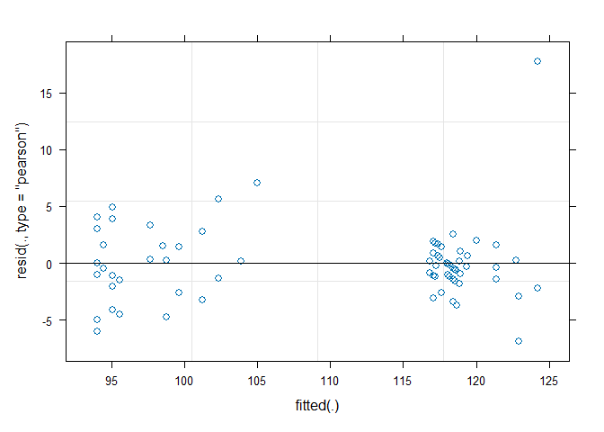

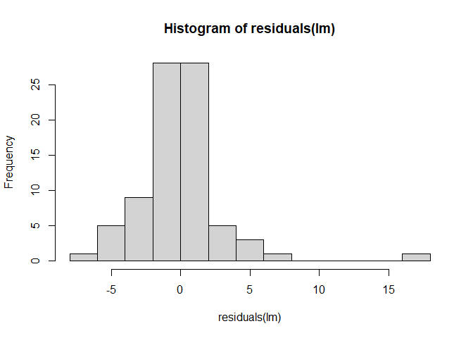

```
## [1] "the number of complete cases is 81"
```

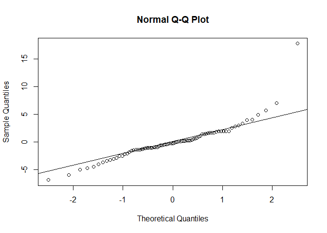

```
## Linear mixed model fit by REML. t-tests use Satterthwaite's method [
## lmerModLmerTest]
## Formula: trait ~ Treatment * Population + (1 | Population:Line)
##    Data: data
##
## REML criterion at convergence: 452.1
##
## Scaled residuals:
##     Min      1Q  Median      3Q     Max
## -1.9630 -0.3998 -0.0758  0.4253  5.0545
##
## Random effects:
##  Groups          Name        Variance Std.Dev.
##  Population:Line (Intercept)  9.626   3.103
##  Residual                    12.340   3.513
## Number of obs: 81, groups:  Population:Line, 18
##
## Fixed effects:
##                         Estimate Std. Error        df t value Pr(>|t|)
## (Intercept)            108.97102    0.89626  15.07011 121.584  < 2e-16 ***
## Treatment1              -0.61197    0.40697  61.04497  -1.504    0.138
## Population1            -10.13711    0.89626  15.07011 -11.310  9.2e-09 ***
## Treatment1:Population1   0.06241    0.40697  61.04497   0.153    0.879
## ---
## Signif. codes:  0 '***' 0.001 '**' 0.01 '*' 0.05 '.' 0.1 ' ' 1
##
## Correlation of Fixed Effects:
##             (Intr) Trtmn1 Ppltn1
## Treatment1  0.009
## Population1 0.334  0.012
## Trtmnt1:Pp1 0.012  0.255  0.009
```

```
## Computing profile confidence intervals ...
```

```
##                              2.5 %      97.5 %
## .sig01                   1.7150412   4.5702900
## .sigma                   2.9302387   4.1678784
## (Intercept)            107.2439959 110.7521954
## Treatment1              -1.4113999   0.1835481
## Population1            -11.8639349  -8.3553158
## Treatment1:Population1  -0.7372144   0.8577559
```

```r
eTof_anov_21 <- do_anov(eTof_lm_21)
```

```
## Type III Analysis of Variance Table with Satterthwaite's method
##                       Sum Sq Mean Sq NumDF  DenDF  F value    Pr(>F)
## Treatment              27.90   27.90     1 61.045   2.2612    0.1378
## Population           1578.55 1578.55     1 15.070 127.9253 9.196e-09 ***
## Treatment:Population    0.29    0.29     1 61.045   0.0235    0.8786
## ---
## Signif. codes:  0 '***' 0.001 '**' 0.01 '*' 0.05 '.' 0.1 ' ' 1
```

```r
eTof_anov_21$trait <- "Emergence To Flowering"
eTof_emmeans_21 <- get_table(eTof_lm_21)
eTof_means_21 <- as.data.frame(eTof_emmeans_21)
eTof_pairs_21 <- as.data.frame(pairs(eTof_emmeans_21))
eTof_pairs_21$trait <- "Emergence To Flowering"

geno_eTof <- as.data.frame(get_geno_table(Dat_2021_most$EmergeToFlwr))
geno_eTof$trait <- "Emergence To Flowering"
```

### Single Leaf Collected At Flowering

fresh weight

```r
# Fresh weight
fresh_lm_21 <- do_lmer(Dat_2021_most$l10_FreshWt)
```

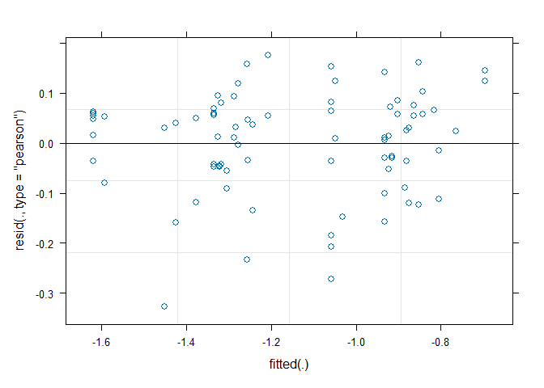

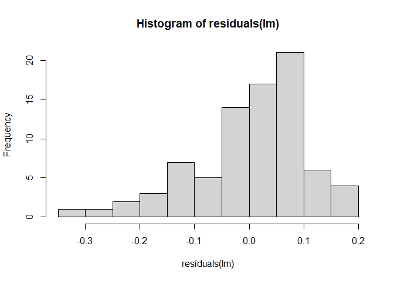

```
## [1] "the number of complete cases is 81"
```

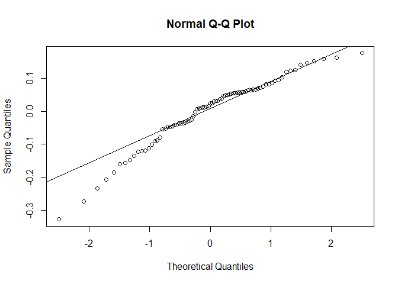

```
## Linear mixed model fit by REML. t-tests use Satterthwaite's method [
## lmerModLmerTest]
## Formula: trait ~ Treatment * Population + (1 | Population:Line)
##    Data: data
##
## REML criterion at convergence: -75
##
## Scaled residuals:
##     Min      1Q  Median      3Q     Max
## -2.8867 -0.4189  0.2063  0.5587  1.5480
##
## Random effects:
##  Groups          Name        Variance Std.Dev.
##  Population:Line (Intercept) 0.01174  0.1084
##  Residual                    0.01281  0.1132
## Number of obs: 81, groups:  Population:Line, 18
##
## Fixed effects:
##                        Estimate Std. Error       df t value Pr(>|t|)
## (Intercept)            -1.12587    0.03073 16.43842 -36.639  < 2e-16 ***
## Treatment1              0.24079    0.01312 62.22968  18.356  < 2e-16 ***
## Population1            -0.02635    0.03073 16.43842  -0.858  0.40347
## Treatment1:Population1  0.03966    0.01312 62.22968   3.023  0.00363 **
## ---
## Signif. codes:  0 '***' 0.001 '**' 0.01 '*' 0.05 '.' 0.1 ' ' 1
##
## Correlation of Fixed Effects:
##             (Intr) Trtmn1 Ppltn1
## Treatment1  0.009
## Population1 0.335  0.011
## Trtmnt1:Pp1 0.011  0.254  0.009
```

```
## Computing profile confidence intervals ...
```

```
##                              2.5 %      97.5 %
## .sig01                  0.06555770  0.15644531
## .sigma                  0.09449334  0.13381093
## (Intercept)            -1.18532077 -1.06535887
## Treatment1              0.21519302  0.26653496
## Population1            -0.08584694  0.03409032
## Treatment1:Population1  0.01407477  0.06541906
```

```r
fresh_anov_21 <- do_anov(fresh_lm_21)
```

```
## Type III Analysis of Variance Table with Satterthwaite's method
##                      Sum Sq Mean Sq NumDF  DenDF  F value  Pr(>F)
## Treatment            4.3171  4.3171     1 62.230 336.9250 < 2e-16 ***
## Population           0.0094  0.0094     1 16.438   0.7354 0.40347
## Treatment:Population 0.1171  0.1171     1 62.230   9.1394 0.00363 **
## ---
## Signif. codes:  0 '***' 0.001 '**' 0.01 '*' 0.05 '.' 0.1 ' ' 1
```

```r
fresh_anov_21$trait <- "l10_FreshWt"
fresh_emmeans_21 <- get_table_bt(fresh_lm_21)
fresh_means_21 <- as.data.frame(fresh_emmeans_21)
fresh_pairs_21 <- as.data.frame(pairs(fresh_emmeans_21))
fresh_pairs_21$trait <- "l10_FreshWt"
```

saturated/hydrated weight

```r
# Saturated weight
sat_lm_21 <- do_lmer(Dat_2021_most$l10_SatWt)
```

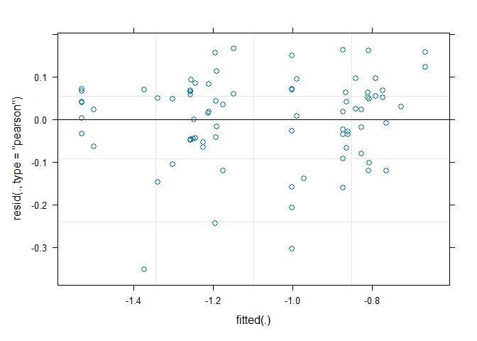

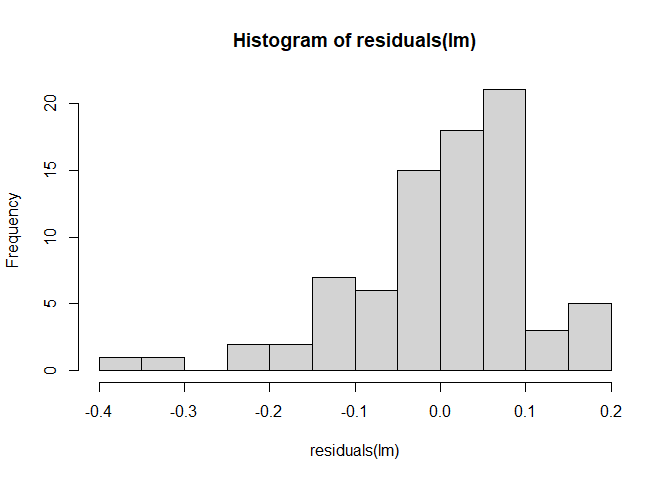

```
## [1] "the number of complete cases is 81"
```

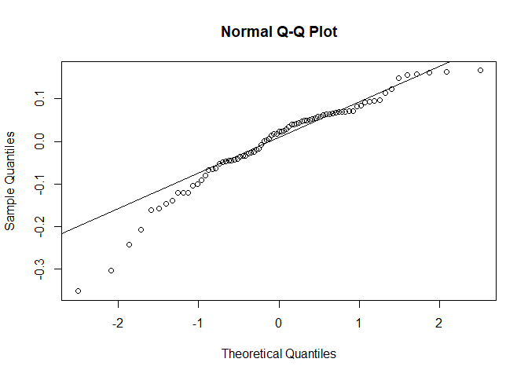

```
## Linear mixed model fit by REML. t-tests use Satterthwaite's method [
## lmerModLmerTest]
## Formula: trait ~ Treatment * Population + (1 | Population:Line)
##    Data: data
##
## REML criterion at convergence: -76.3
##
## Scaled residuals:
##     Min      1Q  Median      3Q     Max
## -3.1055 -0.4174  0.2048  0.5797  1.4690
##
## Random effects:
##  Groups          Name        Variance Std.Dev.
##  Population:Line (Intercept) 0.01043  0.1021
##  Residual                    0.01284  0.1133
## Number of obs: 81, groups:  Population:Line, 18
##
## Fixed effects:
##                        Estimate Std. Error       df t value Pr(>|t|)
## (Intercept)            -1.06183    0.02936 16.51523 -36.163  < 2e-16 ***
## Treatment1              0.22848    0.01313 62.41187  17.403  < 2e-16 ***
## Population1            -0.02693    0.02936 16.51523  -0.917  0.37219
## Treatment1:Population1  0.03627    0.01313 62.41187   2.763  0.00752 **
## ---
## Signif. codes:  0 '***' 0.001 '**' 0.01 '*' 0.05 '.' 0.1 ' ' 1
##
## Correlation of Fixed Effects:
##             (Intr) Trtmn1 Ppltn1
## Treatment1  0.009
## Population1 0.334  0.012
## Trtmnt1:Pp1 0.012  0.255  0.009
```

```
## Computing profile confidence intervals ...
```

```
##                              2.5 %      97.5 %
## .sig01                  0.06057770  0.14844021
## .sigma                  0.09460066  0.13389828
## (Intercept)            -1.11859885 -1.00394945
## Treatment1              0.20286991  0.25424647
## Population1            -0.08374155  0.03087997
## Treatment1:Population1  0.01067229  0.06205116
```

```r
sat_anov_21 <- do_anov(sat_lm_21)
```

```
## Type III Analysis of Variance Table with Satterthwaite's method
##                      Sum Sq Mean Sq NumDF  DenDF  F value    Pr(>F)
## Treatment            3.8888  3.8888     1 62.412 302.8775 < 2.2e-16 ***
## Population           0.0108  0.0108     1 16.515   0.8414  0.372190
## Treatment:Population 0.0980  0.0980     1 62.412   7.6342  0.007516 **
## ---
## Signif. codes:  0 '***' 0.001 '**' 0.01 '*' 0.05 '.' 0.1 ' ' 1
```

```r
sat_anov_21$trait <- "l10_SatWt"
sat_emmeans_21 <- get_table_bt(sat_lm_21)
sat_means_21 <- as.data.frame(sat_emmeans_21)
sat_pairs_21 <- as.data.frame(pairs(sat_emmeans_21))
sat_pairs_21$trait <- "l10_SatWt"
```

dried weight

```r
# Dried weight
dry_lm_21 <- do_lmer(Dat_2021_most$l10_DriedWt)
```

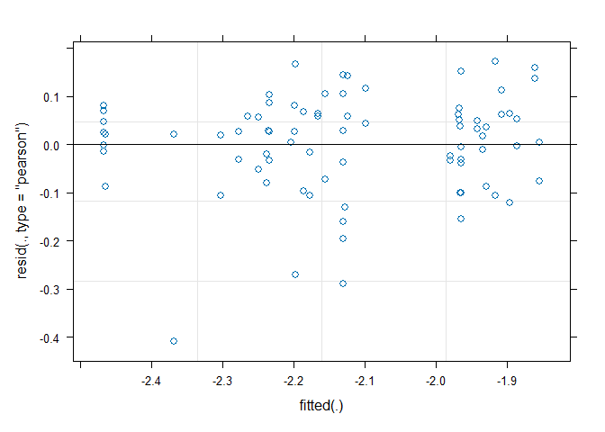

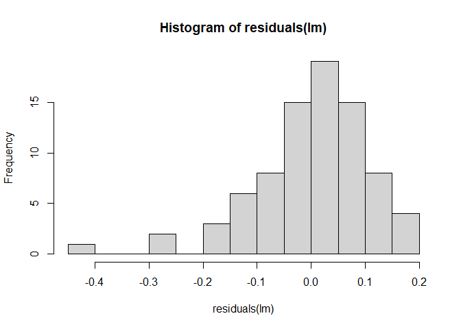

```
## [1] "the number of complete cases is 81"
```

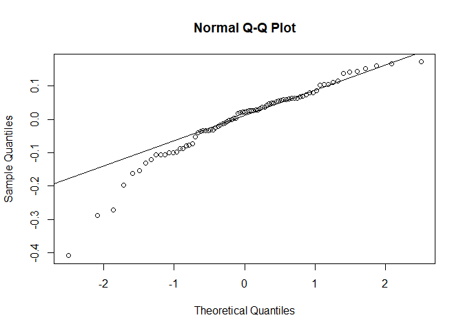

```
## Linear mixed model fit by REML. t-tests use Satterthwaite's method [
## lmerModLmerTest]
## Formula: trait ~ Treatment * Population + (1 | Population:Line)
##    Data: data
##
## REML criterion at convergence: -76.1
##
## Scaled residuals:
##     Min      1Q  Median      3Q     Max
## -3.5595 -0.3468  0.1872  0.5463  1.4987
##
## Random effects:
##  Groups          Name        Variance Std.Dev.
##  Population:Line (Intercept) 0.009056 0.09516
##  Residual                    0.013202 0.11490
## Number of obs: 81, groups:  Population:Line, 18
##
## Fixed effects:
##                        Estimate Std. Error       df t value Pr(>|t|)
## (Intercept)            -2.11903    0.02794 16.30379 -75.837   <2e-16 ***
## Treatment1              0.15148    0.01331 62.40072  11.382   <2e-16 ***
## Population1            -0.04221    0.02794 16.30379  -1.510    0.150
## Treatment1:Population1  0.01671    0.01331 62.40072   1.256    0.214
## ---
## Signif. codes:  0 '***' 0.001 '**' 0.01 '*' 0.05 '.' 0.1 ' ' 1
##
## Correlation of Fixed Effects:
##             (Intr) Trtmn1 Ppltn1
## Treatment1  0.009
## Population1 0.334  0.012
## Trtmnt1:Pp1 0.012  0.255  0.009
```

```
## Computing profile confidence intervals ...
```

```
##                               2.5 %      97.5 %
## .sig01                  0.053593103  0.14001243
## .sigma                  0.095927150  0.13582770
## (Intercept)            -2.173109604 -2.06404956
## Treatment1              0.125527631  0.17761659
## Population1            -0.096304448  0.01274503
## Treatment1:Population1 -0.009230463  0.04286144
```

```r
dry_anov_21 <- do_anov(dry_lm_21)
```

```
## Type III Analysis of Variance Table with Satterthwaite's method
##                       Sum Sq Mean Sq NumDF  DenDF  F value Pr(>F)
## Treatment            1.71044 1.71044     1 62.401 129.5576 <2e-16 ***
## Population           0.03012 0.03012     1 16.304   2.2816 0.1501
## Treatment:Population 0.02082 0.02082     1 62.401   1.5769 0.2139
## ---
## Signif. codes:  0 '***' 0.001 '**' 0.01 '*' 0.05 '.' 0.1 ' ' 1
```

```r
dry_anov_21$trait <- "l10_DriedWt"
dry_emmeans_21 <- get_table_bt(dry_lm_21)
dry_means_21 <- as.data.frame(dry_emmeans_21)
dry_pairs_21 <- as.data.frame(pairs(dry_emmeans_21))
dry_pairs_21$trait <- "l10_DriedWt"

# testing, no meaningfully changes - done before updating lmer and anov to differnt functions
#anov_lmer(Dat_2021_TwoTrt$DriedWt_g)
#anov_lmer(Dat_2021_TwoTrt$SQR_DriedWt)
```

leaf area

```r
# Leaf Area
area_lm_21 <- do_lmer(Dat_2021_la$l10_LeafArea, data = Dat_2021_la)
```

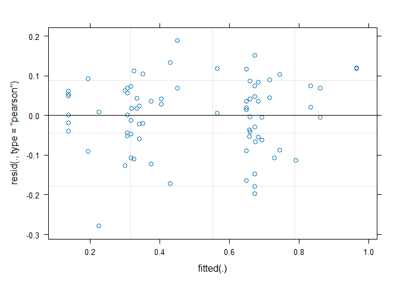

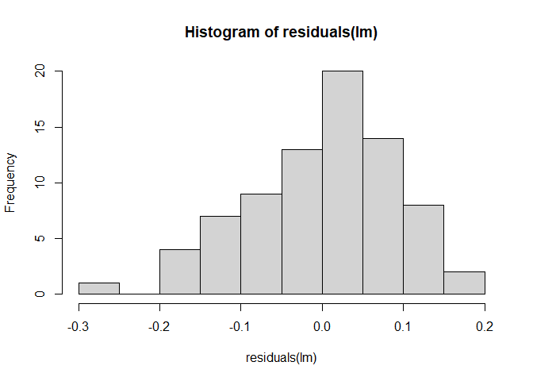

```
## [1] "the number of complete cases is 78"
```

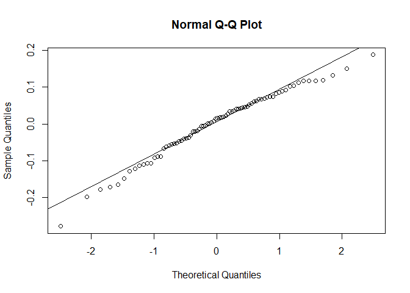

```
## Linear mixed model fit by REML. t-tests use Satterthwaite's method [
## lmerModLmerTest]
## Formula: trait ~ Treatment * Population + (1 | Population:Line)
##    Data: data
##
## REML criterion at convergence: -93
##
## Scaled residuals:
##     Min      1Q  Median      3Q     Max
## -2.8046 -0.5349  0.1522  0.6644  1.8918
##
## Random effects:
##  Groups          Name        Variance Std.Dev.
##  Population:Line (Intercept) 0.007651 0.08747
##  Residual                    0.009895 0.09947
## Number of obs: 78, groups:  Population:Line, 17
##
## Fixed effects:
##                        Estimate Std. Error       df t value Pr(>|t|)
## (Intercept)             0.52860    0.02661 15.17368  19.864 2.83e-12 ***
## Treatment1              0.21896    0.01184 60.59893  18.500  < 2e-16 ***
## Population1             0.01713    0.02661 15.17368   0.644 0.529371
## Treatment1:Population1  0.04861    0.01184 60.59893   4.107 0.000122 ***
## ---
## Signif. codes:  0 '***' 0.001 '**' 0.01 '*' 0.05 '.' 0.1 ' ' 1
##
## Correlation of Fixed Effects:
##             (Intr) Trtmn1 Ppltn1
## Treatment1  0.015
## Population1 0.394  0.009
## Trtmnt1:Pp1 0.009  0.276  0.015
```

```
## Computing profile confidence intervals ...
```

```
##                              2.5 %     97.5 %
## .sig01                  0.05065781 0.12828283
## .sigma                  0.08280792 0.11783507
## (Intercept)             0.47709927 0.58093430
## Treatment1              0.19576194 0.24206926
## Population1            -0.03451131 0.06926863
## Treatment1:Population1  0.02557386 0.07189655
```

```r
area_anov_21 <- do_anov(area_lm_21)
```

```
## Type III Analysis of Variance Table with Satterthwaite's method
##                      Sum Sq Mean Sq NumDF  DenDF  F value    Pr(>F)
## Treatment            3.3866  3.3866     1 60.599 342.2532 < 2.2e-16 ***
## Population           0.0041  0.0041     1 15.174   0.4144 0.5293712
## Treatment:Population 0.1669  0.1669     1 60.599  16.8666 0.0001221 ***
## ---
## Signif. codes:  0 '***' 0.001 '**' 0.01 '*' 0.05 '.' 0.1 ' ' 1
```

```r
area_anov_21$trait <- "l10_area"
area_emmeans_21 <- get_table_bt(area_lm_21)
area_means_21 <- as.data.frame(area_emmeans_21)
area_pairs_21 <- as.data.frame(pairs(area_emmeans_21))
area_pairs_21$trait <- "l10_area"
```

specific leaf area

```r
# SLA
SLA_lm_21 <- do_lmer(Dat_2021_la$l10_SLA, data = Dat_2021_la)
```

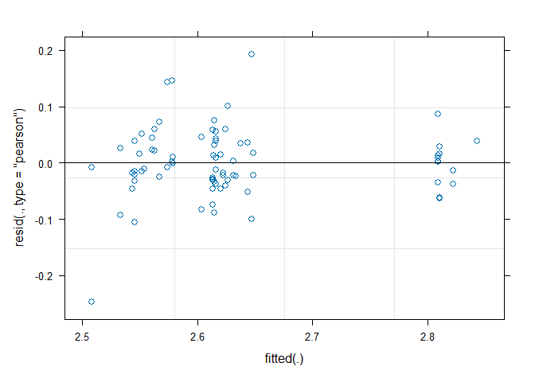

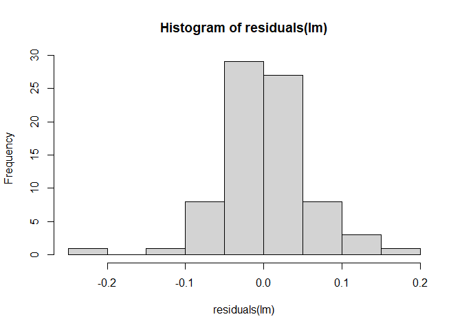

```
## [1] "the number of complete cases is 78"
```

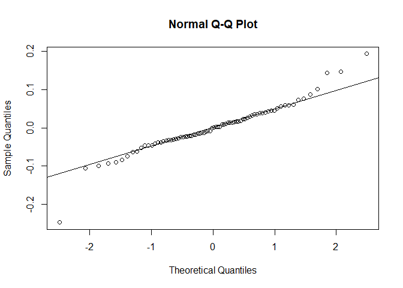

```
## Linear mixed model fit by REML. t-tests use Satterthwaite's method [
## lmerModLmerTest]
## Formula: trait ~ Treatment * Population + (1 | Population:Line)
##    Data: data
##
## REML criterion at convergence: -168.9
##
## Scaled residuals:
##     Min      1Q  Median      3Q     Max
## -3.7958 -0.4795  0.0004  0.5220  2.9620
##
## Random effects:
##  Groups          Name        Variance  Std.Dev.
##  Population:Line (Intercept) 0.0007595 0.02756
##  Residual                    0.0042274 0.06502
## Number of obs: 78, groups:  Population:Line, 17
##
## Fixed effects:
##                         Estimate Std. Error        df t value Pr(>|t|)
## (Intercept)             2.654356   0.010999 10.698049 241.334  < 2e-16 ***
## Treatment1              0.066541   0.007707 59.099837   8.633 4.62e-12 ***
## Population1             0.066734   0.010999 10.698049   6.067 9.11e-05 ***
## Treatment1:Population1  0.031335   0.007707 59.099837   4.066 0.000144 ***
## ---
## Signif. codes:  0 '***' 0.001 '**' 0.01 '*' 0.05 '.' 0.1 ' ' 1
##
## Correlation of Fixed Effects:
##             (Intr) Trtmn1 Ppltn1
## Treatment1  0.015
## Population1 0.362  0.009
## Trtmnt1:Pp1 0.009  0.279  0.015
```

```
## Computing profile confidence intervals ...
```

```
##                             2.5 %     97.5 %
## .sig01                 0.00000000 0.04937850
## .sigma                 0.05412100 0.07823924
## (Intercept)            2.63324163 2.67628215
## Treatment1             0.05108049 0.08147584
## Population1            0.04549173 0.08843306
## Treatment1:Population1 0.01606360 0.04638375
```

```r
SLA_anov_21 <- do_anov(SLA_lm_21)
```

```
## Type III Analysis of Variance Table with Satterthwaite's method
##                        Sum Sq  Mean Sq NumDF  DenDF F value    Pr(>F)
## Treatment            0.315095 0.315095     1 59.100  74.537 4.623e-12 ***
## Population           0.155626 0.155626     1 10.698  36.814 9.111e-05 ***
## Treatment:Population 0.069874 0.069874     1 59.100  16.529 0.0001436 ***
## ---
## Signif. codes:  0 '***' 0.001 '**' 0.01 '*' 0.05 '.' 0.1 ' ' 1
```

```r
SLA_anov_21$trait <- "l10_SLA"
SLA_emmeans_21 <- get_table_bt(SLA_lm_21)
SLA_means_21 <- as.data.frame(SLA_emmeans_21)
SLA_pairs_21 <- as.data.frame(pairs(SLA_emmeans_21))
SLA_pairs_21$trait <- "l10_SLA"

geno_sla_21 <- as.data.frame(get_geno_table_bt(Dat_2021_la$l10_SLA, data = Dat_2021_la))
geno_sla_21$trait <- "l10_SLA"
```

leaf dry matter content

```r
# LDMC
LDMC_lm_21 <- do_lmer(Dat_2021_most$l10_LDMC)
```

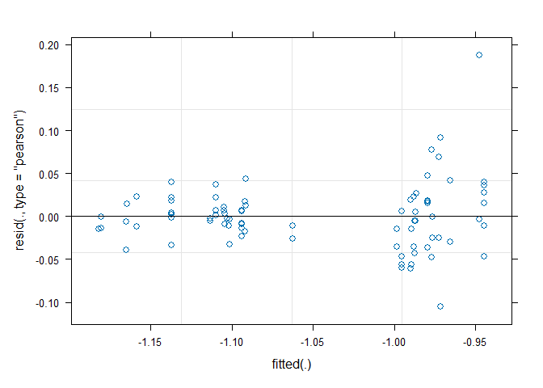

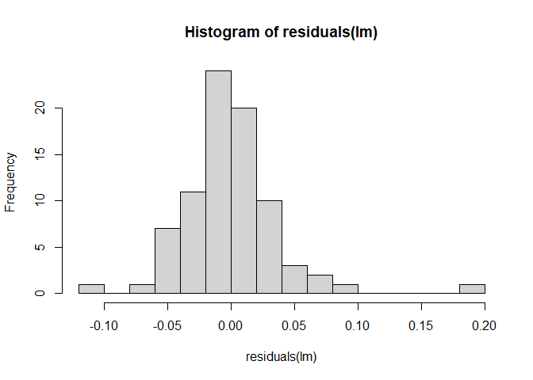

```
## [1] "the number of complete cases is 81"
```

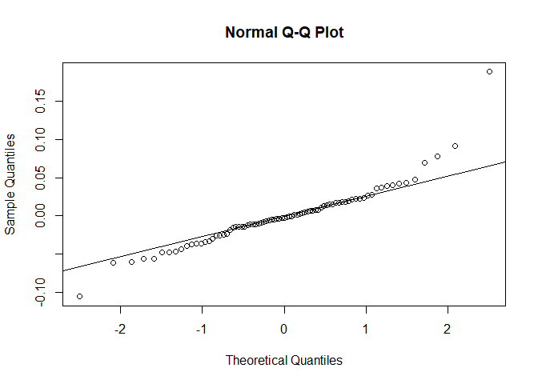

```
## Linear mixed model fit by REML. t-tests use Satterthwaite's method [
## lmerModLmerTest]
## Formula: trait ~ Treatment * Population + (1 | Population:Line)
##    Data: data
##
## REML criterion at convergence: -243.2
##
## Scaled residuals:
##     Min      1Q  Median      3Q     Max
## -2.5369 -0.4338 -0.0523  0.4174  4.5285
##
## Random effects:
##  Groups          Name        Variance  Std.Dev.
##  Population:Line (Intercept) 0.0004247 0.02061
##  Residual                    0.0017169 0.04144
## Number of obs: 81, groups:  Population:Line, 18
##
## Fixed effects:
##                         Estimate Std. Error        df  t value Pr(>|t|)
## (Intercept)            -1.054887   0.007294 15.805027 -144.617  < 2e-16 ***
## Treatment1             -0.076973   0.004789 63.844243  -16.074  < 2e-16 ***
## Population1            -0.013349   0.007294 15.805027   -1.830 0.086161 .
## Treatment1:Population1 -0.019556   0.004789 63.844243   -4.084 0.000126 ***
## ---
## Signif. codes:  0 '***' 0.001 '**' 0.01 '*' 0.05 '.' 0.1 ' ' 1
##
## Correlation of Fixed Effects:
##             (Intr) Trtmn1 Ppltn1
## Treatment1  0.009
## Population1 0.325  0.014
## Trtmnt1:Pp1 0.014  0.257  0.009
```

```
## Computing profile confidence intervals ...
```

```
##                               2.5 %        97.5 %
## .sig01                  0.002529385  0.0337786626
## .sigma                  0.034630086  0.0488857993
## (Intercept)            -1.069651532 -1.0408824965
## Treatment1             -0.086299143 -0.0675635637
## Population1            -0.027987153  0.0006588065
## Treatment1:Population1 -0.028886694 -0.0101524936
```

```r
LDMC_anov_21 <- do_anov(LDMC_lm_21)
```

```
## Type III Analysis of Variance Table with Satterthwaite's method
##                       Sum Sq Mean Sq NumDF  DenDF  F value    Pr(>F)
## Treatment            0.44360 0.44360     1 63.844 258.3769 < 2.2e-16 ***
## Population           0.00575 0.00575     1 15.805   3.3492 0.0861611 .
## Treatment:Population 0.02863 0.02863     1 63.844  16.6781 0.0001258 ***
## ---
## Signif. codes:  0 '***' 0.001 '**' 0.01 '*' 0.05 '.' 0.1 ' ' 1
```

```r
LDMC_anov_21$trait <- "l10_LDMC"
LDMC_emmeans_21 <- get_table_bt(LDMC_lm_21)
LDMC_means_21 <- as.data.frame(LDMC_emmeans_21)
LDMC_pairs_21 <- as.data.frame(pairs(LDMC_emmeans_21))
LDMC_pairs_21$trait <- "l10_LDMC"
```

relative water content

```r
# RWC
RWC_lm_21 <- do_lmer(Dat_2021_most$RWC)
```

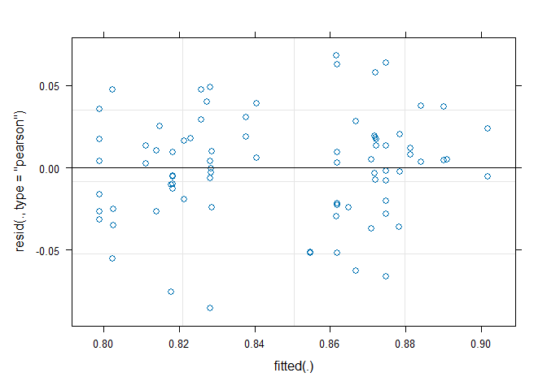

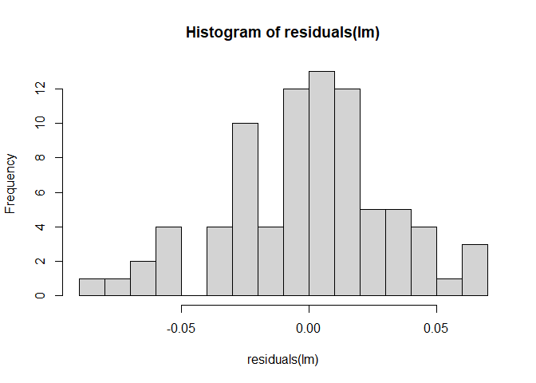

```
## [1] "the number of complete cases is 81"
```

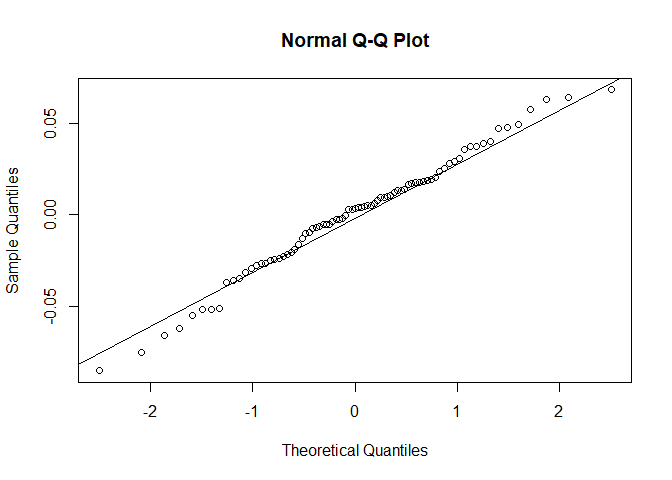

```
## Linear mixed model fit by REML. t-tests use Satterthwaite's method [
## lmerModLmerTest]
## Formula: trait ~ Treatment * Population + (1 | Population:Line)
##    Data: data
##
## REML criterion at convergence: -275.2
##
## Scaled residuals:
##     Min      1Q  Median      3Q     Max
## -2.4951 -0.6363  0.1018  0.5288  1.9937
##
## Random effects:
##  Groups          Name        Variance  Std.Dev.
##  Population:Line (Intercept) 0.0001995 0.01412
##  Residual                    0.0011739 0.03426
## Number of obs: 81, groups:  Population:Line, 18
##
## Fixed effects:
##                          Estimate Std. Error         df t value Pr(>|t|)
## (Intercept)             8.477e-01  5.506e-03  1.425e+01 153.951  < 2e-16 ***
## Treatment1              2.995e-02  3.956e-03  6.353e+01   7.569 1.93e-10 ***
## Population1            -2.344e-06  5.506e-03  1.425e+01   0.000   0.9997
## Treatment1:Population1  8.101e-03  3.956e-03  6.353e+01   2.047   0.0448 *
## ---
## Signif. codes:  0 '***' 0.001 '**' 0.01 '*' 0.05 '.' 0.1 ' ' 1
##
## Correlation of Fixed Effects:
##             (Intr) Trtmn1 Ppltn1
## Treatment1  0.008
## Population1 0.320  0.014
## Trtmnt1:Pp1 0.014  0.257  0.008
```

```
## Computing profile confidence intervals ...
```

```
##                                2.5 %     97.5 %
## .sig01                  0.0000000000 0.02485499
## .sigma                  0.0286384682 0.04054065
## (Intercept)             0.8371251409 0.85870731
## Treatment1              0.0221950251 0.03768718
## Population1            -0.0106182190 0.01089029
## Treatment1:Population1  0.0003666604 0.01585874
```

```r
RWC_anov_21 <- do_anov(RWC_lm_21)
```

```
## Type III Analysis of Variance Table with Satterthwaite's method
##                        Sum Sq  Mean Sq NumDF  DenDF F value    Pr(>F)
## Treatment            0.067258 0.067258     1 63.528 57.2926 1.932e-10 ***
## Population           0.000000 0.000000     1 14.249  0.0000   0.99967
## Treatment:Population 0.004921 0.004921     1 63.528  4.1921   0.04475 *
## ---
## Signif. codes:  0 '***' 0.001 '**' 0.01 '*' 0.05 '.' 0.1 ' ' 1
```

```r
RWC_anov_21$trait <- "RWC"
RWC_emmeans_21 <- get_table(RWC_lm_21)
RWC_means_21 <- as.data.frame(RWC_emmeans_21)
RWC_pairs_21 <- as.data.frame(pairs(RWC_emmeans_21))
RWC_pairs_21$trait <- "RWC"

geno_rwc_21 <- as.data.frame(get_geno_table(Dat_2021_most$RWC))
geno_rwc_21$trait <- "RWC"
```

### Leaf Number

Leaf number at harvest

```r
# LN at harvest - from all plants - hard to count at this point in life cycle
LN_harv_lm_21 <- do_lmer(Dat_2021_most$RosetteLeafNum)
```

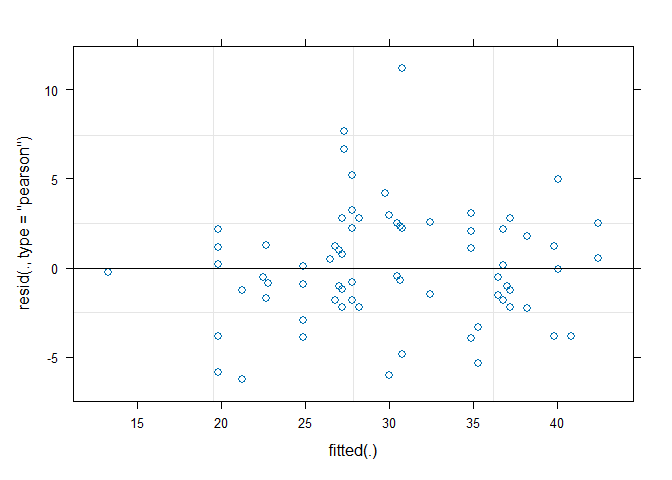

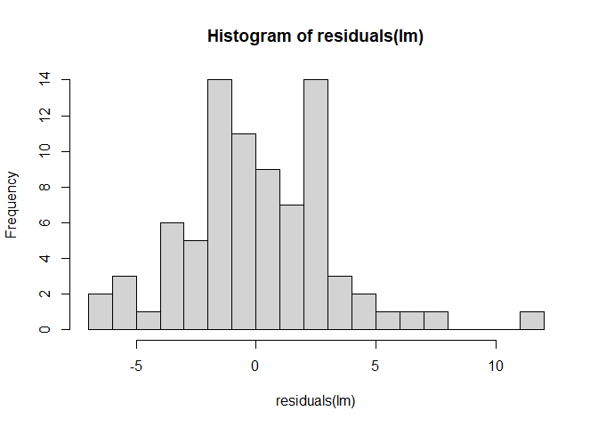

```
## [1] "the number of complete cases is 81"
```

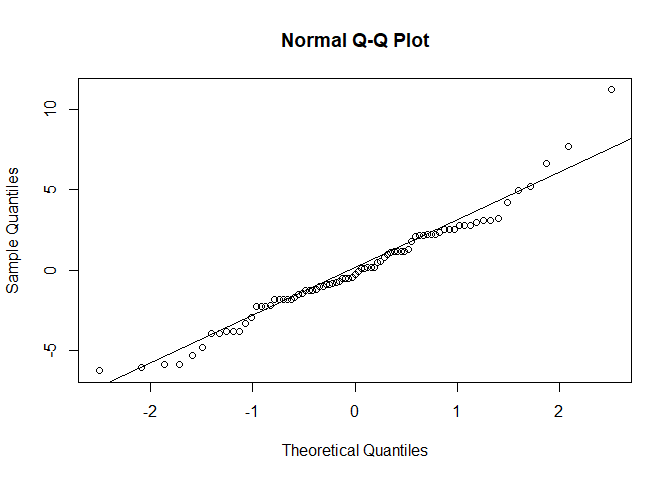

```
## Linear mixed model fit by REML. t-tests use Satterthwaite's method [
## lmerModLmerTest]
## Formula: trait ~ Treatment * Population + (1 | Population:Line)
##    Data: data
##
## REML criterion at convergence: 453.5
##
## Scaled residuals:
##     Min      1Q  Median      3Q     Max
## -1.8034 -0.5231 -0.0793  0.6287  3.2303
##
## Random effects:
##  Groups          Name        Variance Std.Dev.
##  Population:Line (Intercept) 12.57    3.546
##  Residual                    11.99    3.463
## Number of obs: 81, groups:  Population:Line, 18
##
## Fixed effects:
##                        Estimate Std. Error      df t value Pr(>|t|)
## (Intercept)             29.2815     0.9917 15.3590  29.526 5.98e-15 ***
## Treatment1              -4.4968     0.4014 61.0649 -11.204  < 2e-16 ***
## Population1             -3.8802     0.9917 15.3590  -3.913  0.00133 **
## Treatment1:Population1   0.5119     0.4014 61.0649   1.275  0.20701
## ---
## Signif. codes:  0 '***' 0.001 '**' 0.01 '*' 0.05 '.' 0.1 ' ' 1
##
## Correlation of Fixed Effects:
##             (Intr) Trtmn1 Ppltn1
## Treatment1  0.008
## Population1 0.335  0.011
## Trtmnt1:Pp1 0.011  0.254  0.008
```

```
## Computing profile confidence intervals ...
```

```
##                            2.5 %    97.5 %
## .sig01                  2.102181  5.120225
## .sigma                  2.888521  4.107598
## (Intercept)            27.349793 31.219271
## Treatment1             -5.277264 -3.703181
## Population1            -5.818866 -1.949297
## Treatment1:Population1 -0.268887  1.305021
```

```r
LN_harv_anov_21 <- do_anov(LN_harv_lm_21)
```

```
## Type III Analysis of Variance Table with Satterthwaite's method
##                       Sum Sq Mean Sq NumDF  DenDF  F value  Pr(>F)
## Treatment            1505.03 1505.03     1 61.065 125.5295 < 2e-16 ***
## Population            183.54  183.54     1 15.359  15.3081 0.00133 **
## Treatment:Population   19.50   19.50     1 61.065   1.6266 0.20701
## ---
## Signif. codes:  0 '***' 0.001 '**' 0.01 '*' 0.05 '.' 0.1 ' ' 1
```

```r
LN_harv_anov_21$trait <- "LeafNum_harvest"
LN_harv_emmeans_21 <- get_table(LN_harv_lm_21)
LN_harv_means_21 <- as.data.frame(LN_harv_emmeans_21)
LN_harv_pairs_21 <- as.data.frame(pairs(LN_harv_emmeans_21))
LN_harv_pairs_21$trait <- "LeafNum_harvest"
```